# DefaultCreditCart

MojganAmiri

6/23/2020

##Read data set& Assign the header& rename our target variable

```r
uci_creditcard <- read.csv("C:\\Users\\yastr\\OneDrive\\Desktop\\creditcardclients.csv" , header = TRUE)
str(uci_creditcard)
```

```
## 'data.frame':    30001 obs. of  25 variables:
##  $ X  : Factor w/ 30001 levels "1","10","100",..: 30001 1 11112 22223 23335 24446 25557 26668 27779 28890 ...
##  $ X1 : Factor w/ 82 levels "10000","100000",..: 82 14 5 81 48 48 48 49 2 7 ...
##  $ X2 : Factor w/ 3 levels "1","2","SEX": 3 2 2 2 2 1 1 1 2 2 ...
##  $ X3 : Factor w/ 8 levels "0","1","2","3",..: 8 3 3 3 3 3 2 2 3 4 ...
##  $ X4 : Factor w/ 5 levels "0","1","2","3",..: 5 2 3 3 2 2 3 3 3 2 ...
##  $ X5 : Factor w/ 57 levels "21","22","23",..: 57 4 6 14 17 37 17 9 3 8 ...
##  $ X6 : Factor w/ 12 levels "-1","-2","0",..: 12 5 1 3 3 1 3 3 3 3 ...
##  $ X7 : Factor w/ 12 levels "-1","-2","0",..: 12 5 5 3 3 3 3 3 1 3 ...
##  $ X8 : Factor w/ 12 levels "-1","-2","0",..: 12 1 3 3 3 1 3 3 1 5 ...
##  $ X9 : Factor w/ 12 levels "-1","-2","0",..: 12 1 3 3 3 3 3 3 3 3 ...
##  $ X10: Factor w/ 11 levels "-1","-2","0",..: 11 2 3 3 3 3 3 3 3 3 ...
##  $ X11: Factor w/ 11 levels "-1","-2","0",..: 11 2 4 3 3 3 3 3 1 3 ...
##  $ X12: Factor w/ 22724 levels "-1","-10","-100",..: 22724 13345 10030 10924 15026 21268 18423 12835 1993 1518 ...
##  $ X13: Factor w/ 22347 levels "-1","-10","-100",..: 22347 11404 5552 3482 15171 16961 17010 13627 12949 3530 ...
##  $ X14: Factor w/ 22027 levels "-1","-10","-100",..: 22027 18440 9759 3105 15397 12421 16866 14184 17258 2072 ...
##  $ X15: Factor w/ 21549 levels "-1","-10","-100",..: 21549 378 11833 3620 10318 7717 6809 16081 8147 2129 ...
##  $ X16: Factor w/ 21011 levels "-1","-10","-100",..: 21011 385 11971 3950 10407 6477 6841 14580 76 1796 ...
##  $ X17: Factor w/ 20605 levels "-1","-10","-100",..: 20605 415 11339 4234 10458 6345 7002 14057 15748 12215 ...
##  $ X18: Factor w/ 7944 levels "0","1","10","100",..: 7944 1 1 1495 2416 2416 3160 5871 4578 4128 ...
##  $ X19: Factor w/ 7900 levels "0","1","10","100",..: 7900 6671 5 1477 2536 4508 2142 4778 6189 1 ...
##  $ X20: Factor w/ 7519 levels "0","1","10","100",..: 7519 1 5 5 646 6 6163 4292 1 4731 ...
##  $ X21: Factor w/ 6938 levels "0","1","10","100",..: 6938 1 5 5 337 6620 5 2077 5286 5 ...
##  $ X22: Factor w/ 6898 levels "0","1","10","100",..: 6898 1 1 5 263 5777 5 950 1502 5 ...
##  $ X23: Factor w/ 6940 levels "0","1","10","100",..: 6940 1 2003 4751 5 5796 6293 963 1267 5 ...
##  $ Y  : Factor w/ 3 levels "0","1","default payment next month": 3 2 2 1 1 1 1 1 1 1 ...
```

```r
colnames(uci_creditcard) <- unlist(uci_creditcard[1,])
uci_creditcard = uci_creditcard[-1, ]
head(uci_creditcard)
```

```
##   ID LIMIT_BAL SEX EDUCATION MARRIAGE AGE PAY_0 PAY_2 PAY_3 PAY_4 PAY_5 PAY_6
## 2  1     20000   2         2        1  24     2     2    -1    -1    -2    -2
## 3  2    120000   2         2        2  26    -1     2     0     0     0     2
## 4  3     90000   2         2        2  34     0     0     0     0     0     0
## 5  4     50000   2         2        1  37     0     0     0     0     0     0
## 6  5     50000   1         2        1  57    -1     0    -1     0     0     0
## 7  6     50000   1         1        2  37     0     0     0     0     0     0
##   BILL_AMT1 BILL_AMT2 BILL_AMT3 BILL_AMT4 BILL_AMT5 BILL_AMT6 PAY_AMT1 PAY_AMT2
## 2      3913      3102       689         0         0         0        0      689
## 3      2682      1725      2682      3272      3455      3261        0     1000
## 4     29239     14027     13559     14331     14948     15549     1518     1500
## 5     46990     48233     49291     28314     28959     29547     2000     2019
## 6      8617      5670     35835     20940     19146     19131     2000    36681
## 7     64400     57069     57608     19394     19619     20024     2500     1815
##   PAY_AMT3 PAY_AMT4 PAY_AMT5 PAY_AMT6 default payment next month
## 2        0        0        0        0                          1
## 3     1000     1000        0     2000                          1
## 4     1000     1000     1000     5000                          0
## 5     1200     1100     1069     1000                          0
## 6    10000     9000      689      679                          0
## 7      657     1000     1000      800                          0
```

```r
colnames(uci_creditcard)[colnames(uci_creditcard)=="default payment next month"] <- "default_payment"
```

## Convert to character then numeric(This is because factors are stored internally as integers with a table to give the factor level labels. Just using as.numeric will only give the internal integer codes.)

```r
uci_creditcard[, 1:25] <- sapply(uci_creditcard[, 1:25], as.character)
uci_creditcard[, 1:25] <- sapply(uci_creditcard[, 1:25], as.numeric)
str(uci_creditcard)
```

```
## 'data.frame':    30000 obs. of  25 variables:
##  $ ID             : num  1 2 3 4 5 6 7 8 9 10 ...
##  $ LIMIT_BAL      : num  20000 120000 90000 50000 50000 50000 500000 100000 140000 20000 ...
##  $ SEX            : num  2 2 2 2 1 1 1 2 2 1 ...
##  $ EDUCATION      : num  2 2 2 2 2 1 1 2 3 3 ...
##  $ MARRIAGE       : num  1 2 2 1 1 2 2 2 1 2 ...
##  $ AGE            : num  24 26 34 37 57 37 29 23 28 35 ...
##  $ PAY_0          : num  2 -1 0 0 -1 0 0 0 0 -2 ...
##  $ PAY_2          : num  2 2 0 0 0 0 0 -1 0 -2 ...
##  $ PAY_3          : num  -1 0 0 0 -1 0 0 -1 2 -2 ...
##  $ PAY_4          : num  -1 0 0 0 0 0 0 0 0 -2 ...
##  $ PAY_5          : num  -2 0 0 0 0 0 0 0 0 -1 ...
##  $ PAY_6          : num  -2 2 0 0 0 0 0 -1 0 -1 ...
##  $ BILL_AMT1      : num  3913 2682 29239 46990 8617 ...
##  $ BILL_AMT2      : num  3102 1725 14027 48233 5670 ...
##  $ BILL_AMT3      : num  689 2682 13559 49291 35835 ...
##  $ BILL_AMT4      : num  0 3272 14331 28314 20940 ...
##  $ BILL_AMT5      : num  0 3455 14948 28959 19146 ...
##  $ BILL_AMT6      : num  0 3261 15549 29547 19131 ...
##  $ PAY_AMT1       : num  0 0 1518 2000 2000 ...
##  $ PAY_AMT2       : num  689 1000 1500 2019 36681 ...
##  $ PAY_AMT3       : num  0 1000 1000 1200 10000 657 38000 0 432 0 ...
##  $ PAY_AMT4       : num  0 1000 1000 1100 9000 ...
##  $ PAY_AMT5       : num  0 0 1000 1069 689 ...
##  $ PAY_AMT6       : num  0 2000 5000 1000 679 ...
##  $ default_payment: num  1 1 0 0 0 0 0 0 0 0 ...
```

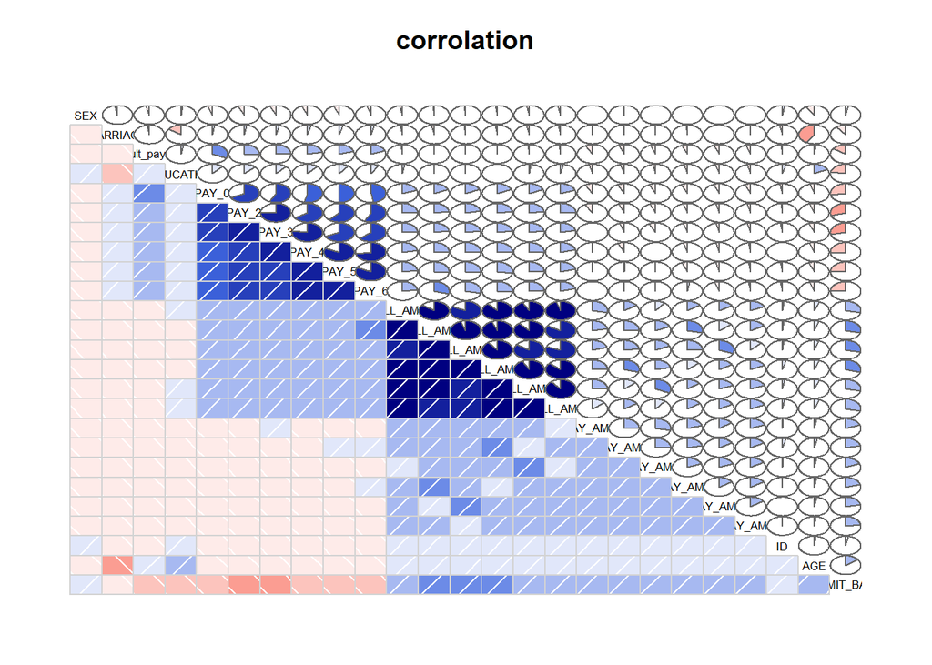

```r
library(corrgram)
library(lazyeval)
corrgram(uci_creditcard, order=TRUE, lower.panel=panel.shade,
         upper.panel=panel.pie, text.panel=panel.txt,
         main="corrolation")
```

#correlation matrix & find highly corolated feature

```r
set.seed(7)
# load the library
library(mlbench)
library(caret)
correlationMatrix <- cor(uci_creditcard[,1:24])
# summarize the correlation matrix
print(correlationMatrix)
```

```
##                      ID   LIMIT_BAL           SEX     EDUCATION     MARRIAGE
## ID         1.0000000000  0.02617916  0.0184974942  0.0391767348 -0.029079425
## LIMIT_BAL  0.0261791577  1.00000000  0.0247552351 -0.2191606982 -0.108139410
## SEX        0.0184974942  0.02475524  1.0000000000  0.0142319362 -0.031388840
## EDUCATION  0.0391767348 -0.21916070  0.0142319362  1.0000000000 -0.143464340
## MARRIAGE  -0.0290794253 -0.10813941 -0.0313888401 -0.1434643404  1.000000000
## AGE        0.0186777345  0.14471280 -0.0908736465  0.1750606615 -0.414169918
## PAY_0     -0.0305749323 -0.27121433 -0.0576428789  0.1053639979  0.019917190
## PAY_2     -0.0112148683 -0.29638210 -0.0707710032  0.1215655525  0.024199067
## PAY_3     -0.0184935538 -0.28612295 -0.0660960564  0.1140249029  0.032687673
## PAY_4     -0.0027348898 -0.26746001 -0.0601732384  0.1087934562  0.033121549
## PAY_5     -0.0221992319 -0.24941139 -0.0550638850  0.0975201606  0.035629170
## PAY_6     -0.0202701341 -0.23519540 -0.0440077882  0.0823159864  0.034344766
## BILL_AMT1  0.0193886739  0.28542986 -0.0336418696  0.0235811807 -0.023471802
## BILL_AMT2  0.0179818975  0.27831436 -0.0311834722  0.0187487708 -0.021601780
## BILL_AMT3  0.0243540500  0.28323578 -0.0245633117  0.0130024007 -0.024909451
## BILL_AMT4  0.0403506029  0.29398762 -0.0218796791 -0.0004513453 -0.023343847
## BILL_AMT5  0.0167053032  0.29556234 -0.0170051802 -0.0075665030 -0.025393398
## BILL_AMT6  0.0167296183  0.29038895 -0.0167331263 -0.0090989547 -0.021206825
## PAY_AMT1   0.0097424435  0.19523592 -0.0002424546 -0.0374561839 -0.005979000
## PAY_AMT2   0.0084061203  0.17840795 -0.0013909097 -0.0300381866 -0.008092703
## PAY_AMT3   0.0391505355  0.21016675 -0.0085966249 -0.0399431409 -0.003541352
## PAY_AMT4   0.0077931297  0.20324241 -0.0022289715 -0.0382181661 -0.012659279
## PAY_AMT5   0.0006521878  0.21720243 -0.0016671618 -0.0403584549 -0.001204757
## PAY_AMT6   0.0029997807  0.21959537 -0.0027660223 -0.0371999031 -0.006640942
##                   AGE       PAY_0       PAY_2        PAY_3        PAY_4
## ID         0.01867773 -0.03057493 -0.01121487 -0.018493554 -0.002734890
## LIMIT_BAL  0.14471280 -0.27121433 -0.29638210 -0.286122954 -0.267460010
## SEX       -0.09087365 -0.05764288 -0.07077100 -0.066096056 -0.060173238
## EDUCATION  0.17506066  0.10536400  0.12156555  0.114024903  0.108793456
## MARRIAGE  -0.41416992  0.01991719  0.02419907  0.032687673  0.033121549
## AGE        1.00000000 -0.03944738 -0.05014778 -0.053048437 -0.049721674
## PAY_0     -0.03944738  1.00000000  0.67216438  0.574245093  0.538840627
## PAY_2     -0.05014778  0.67216438  1.00000000  0.766551683  0.662067131
## PAY_3     -0.05304844  0.57424509  0.76655168  1.000000000  0.777358873
## PAY_4     -0.04972167  0.53884063  0.66206713  0.777358873  1.000000000
## PAY_5     -0.05382598  0.50942606  0.62278025  0.686774511  0.819835311
## PAY_6     -0.04877343  0.47455309  0.57550086  0.632683593  0.716449482
## BILL_AMT1  0.05623853  0.18706843  0.23488653  0.208472889  0.202812069
## BILL_AMT2  0.05428307  0.18985911  0.23525694  0.237294534  0.225816316
```

[output cut: 70 more lines]

```
## PAY_4     -0.069235204 -0.043461430 -0.0335895347 -0.026565088
## PAY_5      0.009062363 -0.058298865 -0.0333365042 -0.023027451
## PAY_6      0.005833774  0.019017863 -0.0464336411 -0.025299338
## BILL_AMT1  0.156887138  0.158302533  0.1670257121  0.179341122
## BILL_AMT2  0.150718194  0.147398104  0.1579574116  0.174256166
## BILL_AMT3  0.130011182  0.143404605  0.1797123504  0.182325966
## BILL_AMT4  0.300022529  0.130191408  0.1604330376  0.177636994
## BILL_AMT5  0.252304862  0.293118463  0.1415741800  0.164184450
## BILL_AMT6  0.233769793  0.250236825  0.3077288895  0.115494167
## PAY_AMT1   0.252191139  0.199557931  0.1484592750  0.185735255
## PAY_AMT2   0.244770450  0.180106744  0.1809077526  0.157633916
## PAY_AMT3   1.000000000  0.216325092  0.1592137203  0.162740033
## PAY_AMT4   0.216325092  1.000000000  0.1518304358  0.157833916
## PAY_AMT5   0.159213720  0.151830436  1.0000000000  0.154895525
## PAY_AMT6   0.162740033  0.157833916  0.1548955253  1.000000000
```

```r
# find attributes that are highly corrected (ideally >0.75)
highlyCorrelated <- findCorrelation(correlationMatrix, cutoff=0.5)
# print indexes of highly correlated attributes
cat("column which are highly corrolated are :" ,highlyCorrelated)
```

```
## column which are highly corrolated are : 16 17 15 18 14 10 9 11 8
```

#forward selection algorithm

```r
str(uci_creditcard)
```

```
## 'data.frame':    30000 obs. of  25 variables:
##  $ ID             : num  1 2 3 4 5 6 7 8 9 10 ...
##  $ LIMIT_BAL      : num  20000 120000 90000 50000 50000 50000 500000 100000 140000 20000 ...
##  $ SEX            : num  2 2 2 2 1 1 1 2 2 1 ...
##  $ EDUCATION      : num  2 2 2 2 2 1 1 2 3 3 ...
##  $ MARRIAGE       : num  1 2 2 1 1 2 2 2 1 2 ...
##  $ AGE            : num  24 26 34 37 57 37 29 23 28 35 ...
##  $ PAY_0          : num  2 -1 0 0 -1 0 0 0 0 -2 ...
##  $ PAY_2          : num  2 2 0 0 0 0 0 -1 0 -2 ...
##  $ PAY_3          : num  -1 0 0 0 -1 0 0 -1 2 -2 ...
##  $ PAY_4          : num  -1 0 0 0 0 0 0 0 0 -2 ...
##  $ PAY_5          : num  -2 0 0 0 0 0 0 0 0 -1 ...
##  $ PAY_6          : num  -2 2 0 0 0 0 0 -1 0 -1 ...
##  $ BILL_AMT1      : num  3913 2682 29239 46990 8617 ...
##  $ BILL_AMT2      : num  3102 1725 14027 48233 5670 ...
##  $ BILL_AMT3      : num  689 2682 13559 49291 35835 ...
##  $ BILL_AMT4      : num  0 3272 14331 28314 20940 ...
##  $ BILL_AMT5      : num  0 3455 14948 28959 19146 ...
##  $ BILL_AMT6      : num  0 3261 15549 29547 19131 ...
##  $ PAY_AMT1       : num  0 0 1518 2000 2000 ...
##  $ PAY_AMT2       : num  689 1000 1500 2019 36681 ...
##  $ PAY_AMT3       : num  0 1000 1000 1200 10000 657 38000 0 432 0 ...
##  $ PAY_AMT4       : num  0 1000 1000 1100 9000 ...
##  $ PAY_AMT5       : num  0 0 1000 1069 689 ...
##  $ PAY_AMT6       : num  0 2000 5000 1000 679 ...
##  $ default_payment: num  1 1 0 0 0 0 0 0 0 0 ...
```

```r
library(MASS)
full <- lm(default_payment~LIMIT_BAL +SEX+ EDUCATION + MARRIAGE +
                                  AGE +PAY_0+PAY_2+ PAY_3+PAY_4+PAY_5+PAY_6+BILL_AMT1+
                                  BILL_AMT2+BILL_AMT3+BILL_AMT4+BILL_AMT5+ BILL_AMT6+
                                  PAY_AMT1+PAY_AMT2+PAY_AMT3+PAY_AMT4+PAY_AMT5+PAY_AMT6,data=uci_creditcard)
null <- lm(default_payment~1,data=uci_creditcard)
stepF <- stepAIC(null, scope=list(lower=null, upper=full), direction= "forward", trace=TRUE)
```

```
## Start:  AIC=-52758.67
## default_payment ~ 1
##
##             Df Sum of Sq    RSS    AIC
## + PAY_0      1    545.19 4622.9 -56101
## + PAY_2      1    358.97 4809.1 -54916
## + PAY_3      1    286.02 4882.1 -54465
## + PAY_4      1    242.50 4925.6 -54198
## + PAY_5      1    215.39 4952.7 -54034
## + PAY_6      1    180.47 4987.7 -53823
## + LIMIT_BAL  1    121.80 5046.3 -53472
## + PAY_AMT1   1     27.49 5140.6 -52917
## + PAY_AMT2   1     17.73 5150.4 -52860
## + PAY_AMT4   1     16.69 5151.4 -52854
## + PAY_AMT3   1     16.35 5151.8 -52852
## + PAY_AMT5   1     15.70 5152.4 -52848
## + PAY_AMT6   1     14.62 5153.5 -52842
## + SEX        1      8.25 5159.9 -52805
## + EDUCATION  1      4.05 5164.1 -52780
## + MARRIAGE   1      3.06 5165.1 -52774
## + BILL_AMT1  1      1.99 5166.1 -52768
## + BILL_AMT2  1      1.04 5167.1 -52763
## + BILL_AMT3  1      1.02 5167.1 -52763
## + AGE        1      1.00 5167.1 -52762
## + BILL_AMT4  1      0.53 5167.6 -52760
## <none>                   5168.1 -52759
## + BILL_AMT5  1      0.24 5167.9 -52758
## + BILL_AMT6  1      0.15 5168.0 -52758
##
## Step:  AIC=-56101.08
## default_payment ~ PAY_0
##
##             Df Sum of Sq    RSS    AIC
## + BILL_AMT1  1    34.621 4588.3 -56325
## + BILL_AMT2  1    30.852 4592.1 -56300
## + BILL_AMT3  1    28.048 4594.9 -56282
## + BILL_AMT4  1    24.933 4598.0 -56261
## + LIMIT_BAL  1    23.883 4599.0 -56254
## + BILL_AMT5  1    22.871 4600.1 -56248
## + BILL_AMT6  1    21.078 4601.8 -56236
```

[output cut: 300 more lines]

```
## Step:  AIC=-56697.79
## default_payment ~ PAY_0 + BILL_AMT1 + PAY_2 + AGE + PAY_3 + PAY_AMT1 +
##     MARRIAGE + LIMIT_BAL + EDUCATION + SEX + PAY_5 + PAY_AMT2 +
##     BILL_AMT2 + PAY_AMT5 + PAY_AMT4
##
##             Df Sum of Sq    RSS    AIC
## <none>                   4527.7 -56698
## + BILL_AMT6  1  0.138659 4527.5 -56697
## + PAY_AMT6   1  0.137275 4527.5 -56697
## + PAY_4      1  0.124959 4527.5 -56697
## + PAY_AMT3   1  0.041401 4527.6 -56696
## + BILL_AMT5  1  0.037107 4527.6 -56696
## + PAY_6      1  0.026502 4527.6 -56696
## + BILL_AMT3  1  0.025303 4527.6 -56696
## + BILL_AMT4  1  0.000144 4527.7 -56696
```

```r
summary(stepF)
```

```
##
## Call:
## lm(formula = default_payment ~ PAY_0 + BILL_AMT1 + PAY_2 + AGE +
##     PAY_3 + PAY_AMT1 + MARRIAGE + LIMIT_BAL + EDUCATION + SEX +
##     PAY_5 + PAY_AMT2 + BILL_AMT2 + PAY_AMT5 + PAY_AMT4, data = uci_creditcard)
##
## Residuals:
##      Min       1Q   Median       3Q      Max
## -1.29593 -0.24069 -0.16146  0.03364  1.27539
##
## Coefficients:
##               Estimate Std. Error t value Pr(>|t|)
## (Intercept)  3.141e-01  1.791e-02  17.542  < 2e-16 ***
## PAY_0        9.601e-02  2.758e-03  34.819  < 2e-16 ***
## BILL_AMT1   -6.428e-07  1.131e-07  -5.683 1.34e-08 ***
## PAY_2        1.945e-02  3.334e-03   5.833 5.49e-09 ***
## AGE          1.414e-03  2.748e-04   5.144 2.71e-07 ***
## PAY_3        1.306e-02  3.263e-03   4.003 6.28e-05 ***
## PAY_AMT1    -8.027e-07  1.689e-07  -4.753 2.02e-06 ***
## MARRIAGE    -2.388e-02  4.766e-03  -5.010 5.47e-07 ***
## LIMIT_BAL   -9.340e-08  2.123e-08  -4.399 1.09e-05 ***
## EDUCATION   -1.518e-02  3.010e-03  -5.043 4.62e-07 ***
## SEX         -1.442e-02  4.639e-03  -3.108  0.00189 **
## PAY_5        8.258e-03  2.828e-03   2.920  0.00351 **
## PAY_AMT2    -1.973e-07  1.048e-07  -1.882  0.05986 .
## BILL_AMT2    2.122e-07  1.202e-07   1.765  0.07753 .
## PAY_AMT5    -2.755e-07  1.540e-07  -1.789  0.07362 .
## PAY_AMT4    -2.166e-07  1.511e-07  -1.434  0.15165
## ---
## Signif. codes:  0 '***' 0.001 '**' 0.01 '*' 0.05 '.' 0.1 ' ' 1
##
## Residual standard error: 0.3886 on 29984 degrees of freedom
## Multiple R-squared:  0.1239, Adjusted R-squared:  0.1235
## F-statistic: 282.8 on 15 and 29984 DF,  p-value: < 2.2e-16
```

#Backward selection algorithm

```r
full <- lm(default_payment~LIMIT_BAL +SEX+ EDUCATION + MARRIAGE +
                                  AGE +PAY_0+PAY_2+ PAY_3+PAY_4+PAY_5+PAY_6+BILL_AMT1+
                                  BILL_AMT2+BILL_AMT3+BILL_AMT4+BILL_AMT5+ BILL_AMT6+
                                  PAY_AMT1+PAY_AMT2+PAY_AMT3+PAY_AMT4+PAY_AMT5+PAY_AMT6,data=uci_creditcard)
stepB <- stepAIC(full, direction= "backward", trace=TRUE)
```

```
## Start:  AIC=-56684.88
## default_payment ~ LIMIT_BAL + SEX + EDUCATION + MARRIAGE + AGE +
##     PAY_0 + PAY_2 + PAY_3 + PAY_4 + PAY_5 + PAY_6 + BILL_AMT1 +
##     BILL_AMT2 + BILL_AMT3 + BILL_AMT4 + BILL_AMT5 + BILL_AMT6 +
##     PAY_AMT1 + PAY_AMT2 + PAY_AMT3 + PAY_AMT4 + PAY_AMT5 + PAY_AMT6
##
##             Df Sum of Sq    RSS    AIC
## - BILL_AMT5  1     0.002 4527.2 -56687
## - PAY_AMT3   1     0.004 4527.2 -56687
## - BILL_AMT3  1     0.006 4527.2 -56687
## - PAY_6      1     0.008 4527.2 -56687
## - BILL_AMT4  1     0.028 4527.2 -56687
## - PAY_AMT6   1     0.077 4527.3 -56686
## - BILL_AMT6  1     0.094 4527.3 -56686
## - PAY_4      1     0.108 4527.3 -56686
## - BILL_AMT2  1     0.148 4527.3 -56686
## - PAY_5      1     0.265 4527.5 -56685
## - PAY_AMT4   1     0.284 4527.5 -56685
## <none>                   4527.2 -56685
## - PAY_AMT2   1     0.312 4527.5 -56685
## - PAY_AMT5   1     0.482 4527.7 -56684
## - SEX        1     1.480 4528.7 -56677
## - PAY_3      1     1.601 4528.8 -56676
## - LIMIT_BAL  1     2.656 4529.8 -56669
## - PAY_AMT1   1     2.665 4529.9 -56669
## - MARRIAGE   1     3.770 4531.0 -56662
## - EDUCATION  1     3.809 4531.0 -56662
## - AGE        1     3.971 4531.2 -56661
## - BILL_AMT1  1     4.491 4531.7 -56657
## - PAY_2      1     5.129 4532.3 -56653
## - PAY_0      1   180.765 4708.0 -55512
##
## Step:  AIC=-56686.87
## default_payment ~ LIMIT_BAL + SEX + EDUCATION + MARRIAGE + AGE +
##     PAY_0 + PAY_2 + PAY_3 + PAY_4 + PAY_5 + PAY_6 + BILL_AMT1 +
##     BILL_AMT2 + BILL_AMT3 + BILL_AMT4 + BILL_AMT6 + PAY_AMT1 +
##     PAY_AMT2 + PAY_AMT3 + PAY_AMT4 + PAY_AMT5 + PAY_AMT6
##
##             Df Sum of Sq    RSS    AIC
## - PAY_AMT3   1     0.004 4527.2 -56689
```

[output cut: 192 more lines]

```
## - PAY_AMT4   1     0.310 4528.0 -56698
## - BILL_AMT2  1     0.471 4528.1 -56697
## - PAY_AMT5   1     0.483 4528.1 -56697
## - PAY_AMT2   1     0.535 4528.2 -56696
## - PAY_5      1     1.287 4528.9 -56691
## - SEX        1     1.459 4529.1 -56690
## - PAY_3      1     2.419 4530.1 -56684
## - LIMIT_BAL  1     2.922 4530.6 -56680
## - PAY_AMT1   1     3.411 4531.1 -56677
## - MARRIAGE   1     3.790 4531.4 -56675
## - EDUCATION  1     3.840 4531.5 -56674
## - AGE        1     3.995 4531.7 -56673
## - BILL_AMT1  1     4.877 4532.5 -56667
## - PAY_2      1     5.138 4532.8 -56666
## - PAY_0      1   183.065 4710.7 -55511
```

```r
summary(stepB)
```

```
##
## Call:
## lm(formula = default_payment ~ LIMIT_BAL + SEX + EDUCATION +
##     MARRIAGE + AGE + PAY_0 + PAY_2 + PAY_3 + PAY_5 + BILL_AMT1 +
##     BILL_AMT2 + PAY_AMT1 + PAY_AMT2 + PAY_AMT4 + PAY_AMT5, data = uci_creditcard)
##
## Residuals:
##      Min       1Q   Median       3Q      Max
## -1.29593 -0.24069 -0.16146  0.03364  1.27539
##
## Coefficients:
##               Estimate Std. Error t value Pr(>|t|)
## (Intercept)  3.141e-01  1.791e-02  17.542  < 2e-16 ***
## LIMIT_BAL   -9.340e-08  2.123e-08  -4.399 1.09e-05 ***
## SEX         -1.442e-02  4.639e-03  -3.108  0.00189 **
## EDUCATION   -1.518e-02  3.010e-03  -5.043 4.62e-07 ***
## MARRIAGE    -2.388e-02  4.766e-03  -5.010 5.47e-07 ***
## AGE          1.414e-03  2.748e-04   5.144 2.71e-07 ***
## PAY_0        9.601e-02  2.758e-03  34.819  < 2e-16 ***
## PAY_2        1.945e-02  3.334e-03   5.833 5.49e-09 ***
## PAY_3        1.306e-02  3.263e-03   4.003 6.28e-05 ***
## PAY_5        8.258e-03  2.828e-03   2.920  0.00351 **
## BILL_AMT1   -6.428e-07  1.131e-07  -5.683 1.34e-08 ***
## BILL_AMT2    2.122e-07  1.202e-07   1.765  0.07753 .
## PAY_AMT1    -8.027e-07  1.689e-07  -4.753 2.02e-06 ***
## PAY_AMT2    -1.973e-07  1.048e-07  -1.882  0.05986 .
## PAY_AMT4    -2.166e-07  1.511e-07  -1.434  0.15165
## PAY_AMT5    -2.755e-07  1.540e-07  -1.789  0.07362 .
## ---
## Signif. codes:  0 '***' 0.001 '**' 0.01 '*' 0.05 '.' 0.1 ' ' 1
##
## Residual standard error: 0.3886 on 29984 degrees of freedom
## Multiple R-squared:  0.1239, Adjusted R-squared:  0.1235
## F-statistic: 282.8 on 15 and 29984 DF,  p-value: < 2.2e-16
```

# Convert Sex Data (1,2) with (Male, Female)

# Convert Education Level Data (0,1,2,3,4,5,6) with (Unknown, Graduate school, University, High school, Others, Unknown, Unknown)

# Convert Marriage level Data (0,1,2,3) with (Unknown, Married, Single, Others)

# Convert default.payment.next.month level Data (0,1) with (No, Yes)

# Convert Repayment Status columns to Factors

```r
uci_creditcard$SEX <- as.factor(uci_creditcard$SEX)
levels(uci_creditcard$SEX) <- c("Male","Female")

uci_creditcard$EDUCATION <- as.factor(uci_creditcard$EDUCATION)
levels(uci_creditcard$EDUCATION) <- c("Unknown", "Graduate School", "University", "High school", "Others", "Unknown", "Unknown")

uci_creditcard$MARRIAGE <- as.factor(uci_creditcard$MARRIAGE)
levels(uci_creditcard$MARRIAGE) <- c("Unknown" , "Married" , "Single" ,"Others")

uci_creditcard$default_payment <- as.factor(uci_creditcard$default_payment)
levels(uci_creditcard$default_payment) <- c("No" , "Yes")

uci_creditcard$PAY_0 <- as.factor(uci_creditcard$PAY_0)
uci_creditcard$PAY_2 <- as.factor(uci_creditcard$PAY_2)
uci_creditcard$PAY_3 <- as.factor(uci_creditcard$PAY_3)
uci_creditcard$PAY_4 <- as.factor(uci_creditcard$PAY_4)
uci_creditcard$PAY_5 <- as.factor(uci_creditcard$PAY_5)
uci_creditcard$PAY_6 <- as.factor(uci_creditcard$PAY_6)
```

# Summary data & Drop the ID Column & Check for Null value & dimantion of data

```r
summary(uci_creditcard)
```

```
##        ID          LIMIT_BAL           SEX                  EDUCATION
##  Min.   :    1   Min.   :  10000   Male  :11888   Unknown        :  345
##  1st Qu.: 7501   1st Qu.:  50000   Female:18112   Graduate School:10585
##  Median :15000   Median : 140000                  University     :14030
##  Mean   :15000   Mean   : 167484                  High school    : 4917
##  3rd Qu.:22500   3rd Qu.: 240000                  Others         :  123
##  Max.   :30000   Max.   :1000000
##
##     MARRIAGE          AGE            PAY_0           PAY_2
##  Unknown:   54   Min.   :21.00   0      :14737   0      :15730
##  Married:13659   1st Qu.:28.00   -1     : 5686   -1     : 6050
##  Single :15964   Median :34.00   1      : 3688   2      : 3927
##  Others :  323   Mean   :35.49   -2     : 2759   -2     : 3782
##                  3rd Qu.:41.00   2      : 2667   3      :  326
##                  Max.   :79.00   3      :  322   4      :   99
##                                  (Other):  141   (Other):   86
##      PAY_3           PAY_4           PAY_5           PAY_6
##  0      :15764   0      :16455   0      :16947   0      :16286
##  -1     : 5938   -1     : 5687   -1     : 5539   -1     : 5740
##  -2     : 4085   -2     : 4348   -2     : 4546   -2     : 4895
##  2      : 3819   2      : 3159   2      : 2626   2      : 2766
##  3      :  240   3      :  180   3      :  178   3      :  184
##  4      :   76   4      :   69   4      :   84   4      :   49
##  (Other):   78   (Other):  102   (Other):   80   (Other):   80
##    BILL_AMT1         BILL_AMT2        BILL_AMT3         BILL_AMT4
##  Min.   :-165580   Min.   :-69777   Min.   :-157264   Min.   :-170000
##  1st Qu.:   3559   1st Qu.:  2985   1st Qu.:   2666   1st Qu.:   2327
##  Median :  22382   Median : 21200   Median :  20089   Median :  19052
##  Mean   :  51223   Mean   : 49179   Mean   :  47013   Mean   :  43263
##  3rd Qu.:  67091   3rd Qu.: 64006   3rd Qu.:  60165   3rd Qu.:  54506
##  Max.   : 964511   Max.   :983931   Max.   :1664089   Max.   : 891586
##
##    BILL_AMT5        BILL_AMT6          PAY_AMT1         PAY_AMT2
##  Min.   :-81334   Min.   :-339603   Min.   :     0   Min.   :      0
##  1st Qu.:  1763   1st Qu.:   1256   1st Qu.:  1000   1st Qu.:    833
##  Median : 18105   Median :  17071   Median :  2100   Median :   2009
##  Mean   : 40311   Mean   :  38872   Mean   :  5664   Mean   :   5921
##  3rd Qu.: 50191   3rd Qu.:  49198   3rd Qu.:  5006   3rd Qu.:   5000
##  Max.   :927171   Max.   : 961664   Max.   :873552   Max.   :1684259
##
##     PAY_AMT3         PAY_AMT4         PAY_AMT5           PAY_AMT6
##  Min.   :     0   Min.   :     0   Min.   :     0.0   Min.   :     0.0
##  1st Qu.:   390   1st Qu.:   296   1st Qu.:   252.5   1st Qu.:   117.8
##  Median :  1800   Median :  1500   Median :  1500.0   Median :  1500.0
##  Mean   :  5226   Mean   :  4826   Mean   :  4799.4   Mean   :  5215.5
##  3rd Qu.:  4505   3rd Qu.:  4013   3rd Qu.:  4031.5   3rd Qu.:  4000.0
##  Max.   :896040   Max.   :621000   Max.   :426529.0   Max.   :528666.0
##
##  default_payment
##  No :23364
##  Yes: 6636
##
##
##
##
##
```

```r
uci_creditcard$ID <- NULL
sum(is.na(uci_creditcard))
```

```
## [1] 0
```

```r
dim(uci_creditcard)
```

```
## [1] 30000    24
```

```r
ncol(uci_creditcard)
```

```
## [1] 24
```

```r
nrow(uci_creditcard)
```

```
## [1] 30000
```

#distrubution of target value

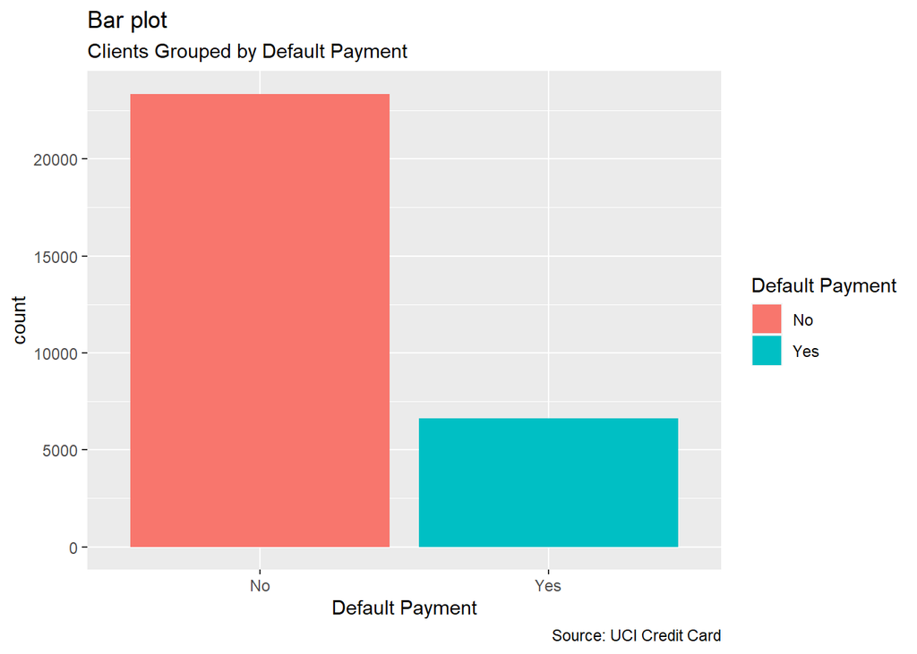

```r
library(ggplot2)
ggplot(uci_creditcard, aes(x=default_payment, fill = default_payment)) +
  geom_bar() +
  labs(title="Bar plot",
       subtitle="Clients Grouped by Default Payment",
       caption="Source: UCI Credit Card",
       x="Default Payment",
       fill="Default Payment")
```

## Plot data using combination of demographic attributes

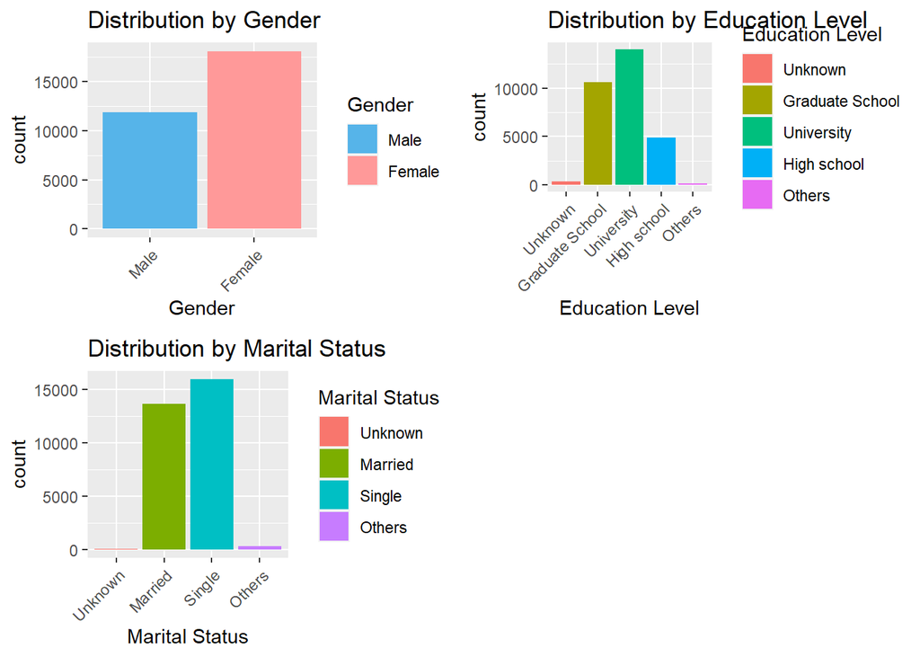

```r
library(gridExtra)
graph1 <- ggplot(data=uci_creditcard, aes(x=SEX,fill=SEX)) + geom_bar() +
  labs(title = "Distribution by Gender", x ="Gender",fill = "Gender") +
  scale_fill_manual(values=c("#56B4E9", "#FF9999")) +
  theme(axis.text.x = element_text(angle = 45,hjust=1))

graph2 <- ggplot(data=uci_creditcard, aes(x=EDUCATION,fill=EDUCATION)) + geom_bar() +
  labs(title = "Distribution by Education Level", x ="Education Level",fill = "Education Level") +
  theme(axis.text.x = element_text(angle = 45,hjust=1))

graph3 <- ggplot(data=uci_creditcard, aes(x=MARRIAGE,fill=MARRIAGE)) + geom_bar() +
  labs(title = "Distribution by Marital Status", x ="Marital Status",fill = "Marital Status") +
  theme(axis.text.x = element_text(angle = 45,hjust=1))

grid.arrange(graph1,graph2,graph3,ncol=2)
```

# Plot data using combination of demographic attributes

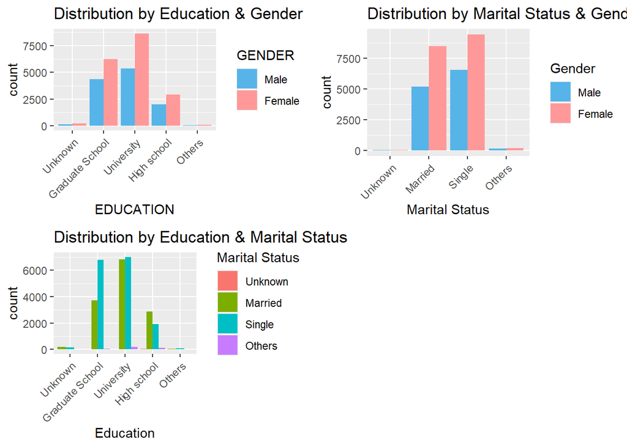

```r
graph4 <- ggplot(data=uci_creditcard, aes(x=EDUCATION,fill=SEX)) + geom_bar(position='dodge') +
  labs(title = "Distribution by Education & Gender", x ="EDUCATION",fill = "GENDER") +
  scale_fill_manual(values=c("#56B4E9", "#FF9999")) +
  theme(axis.text.x = element_text(angle = 45,hjust=1))

graph5 <- ggplot(data=uci_creditcard, aes(x=MARRIAGE,fill=SEX)) + geom_bar(position='dodge') +
  labs(title = "Distribution by Marital Status & Gender", x ="Marital Status",fill = "Gender") +
  scale_fill_manual(values=c("#56B4E9", "#FF9999")) +
  theme(axis.text.x = element_text(angle = 45,hjust=1))

graph6 <- ggplot(data=uci_creditcard, aes(x=EDUCATION,fill=MARRIAGE)) + geom_bar(position='dodge') +
  labs(title = "Distribution by Education & Marital Status", x ="Education",fill = "Marital Status") +
  theme(axis.text.x = element_text(angle = 45,hjust=1))

grid.arrange(graph4, graph5, graph6,ncol=2)
```

#Plot SEX,LIMIT_BAL,EDUCATION VS default_payment

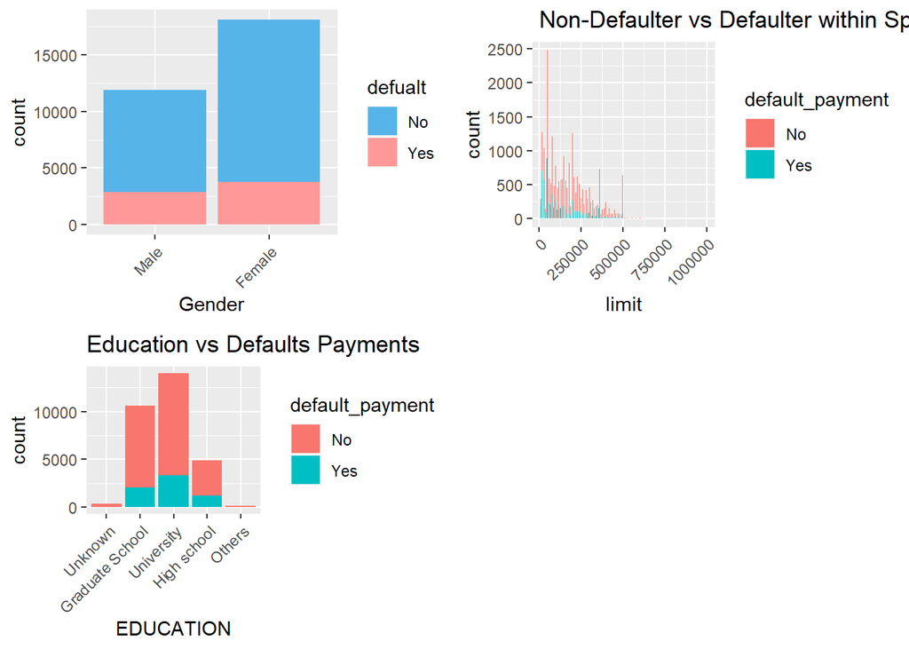

```r
graph7 <- ggplot(data=uci_creditcard, aes(x=SEX,fill=default_payment)) + geom_bar() +
  labs( x ="Gender",fill = "defualt") +
  scale_fill_manual(values=c("#56B4E9", "#FF9999")) +
  theme(axis.text.x = element_text(angle = 45,hjust=1))

graph8 <- ggplot(data=uci_creditcard, aes(x=LIMIT_BAL,fill=default_payment)) + geom_bar() +
  labs(title = " Non-Defaulter vs Defaulter within Specific Credit Limit Group", x ="limit",fill = "default_payment") +
  theme(axis.text.x = element_text(angle = 45,hjust=1))

graph9 <- ggplot(data=uci_creditcard, aes(x=EDUCATION,fill=default_payment)) + geom_bar() +
  labs(title = "Education vs Defaults Payments", x ="EDUCATION",fill = "default_payment") +
  theme(axis.text.x = element_text(angle = 45,hjust=1))
grid.arrange(graph7, graph8, graph9,ncol=2)
```

#Histogram PAY_X

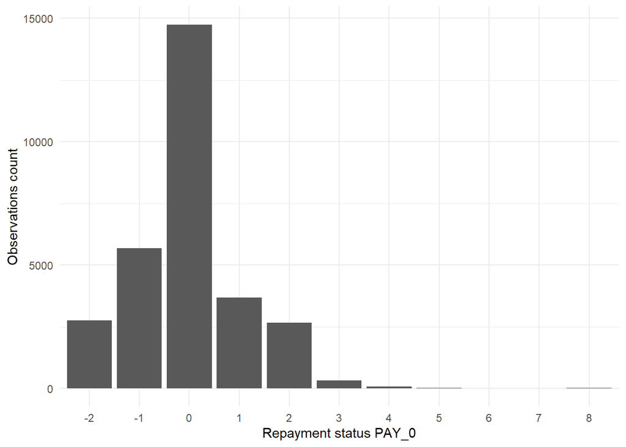

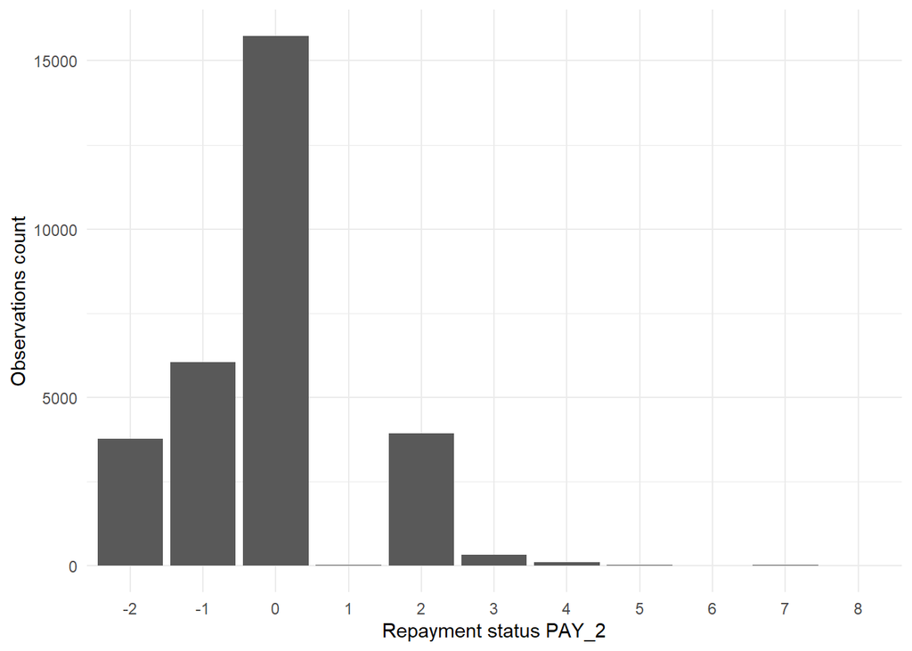

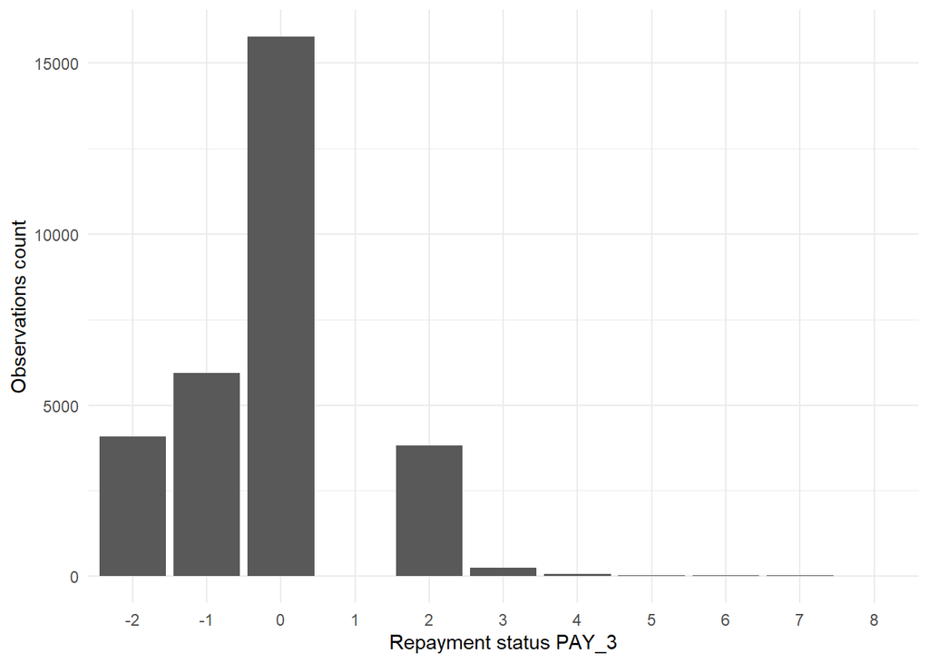

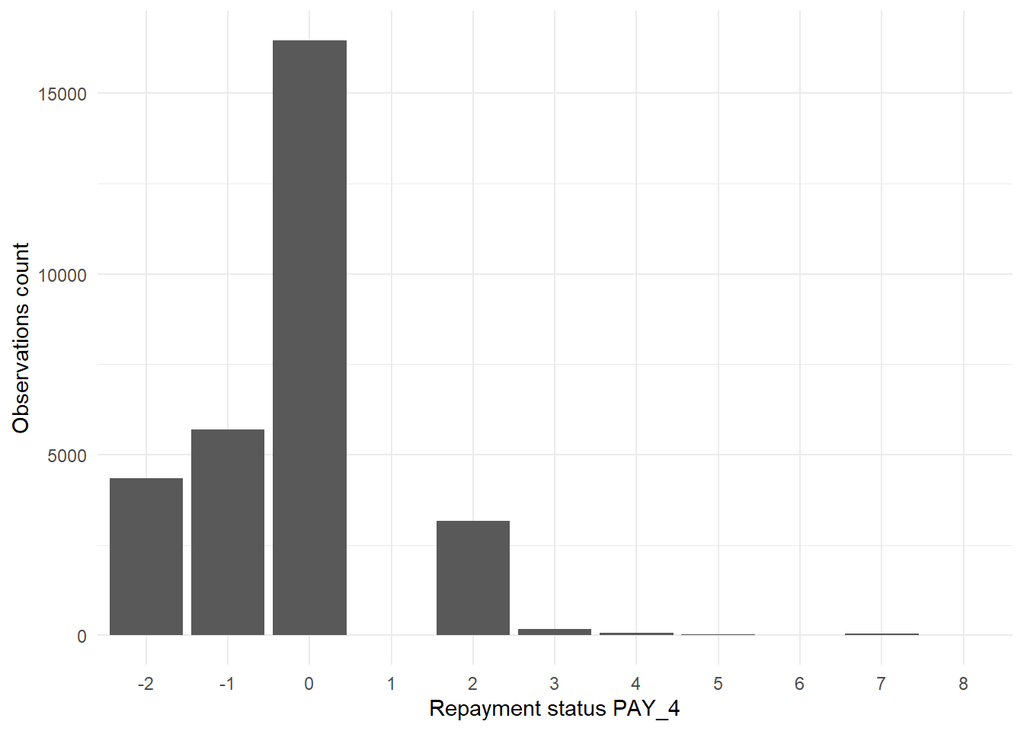

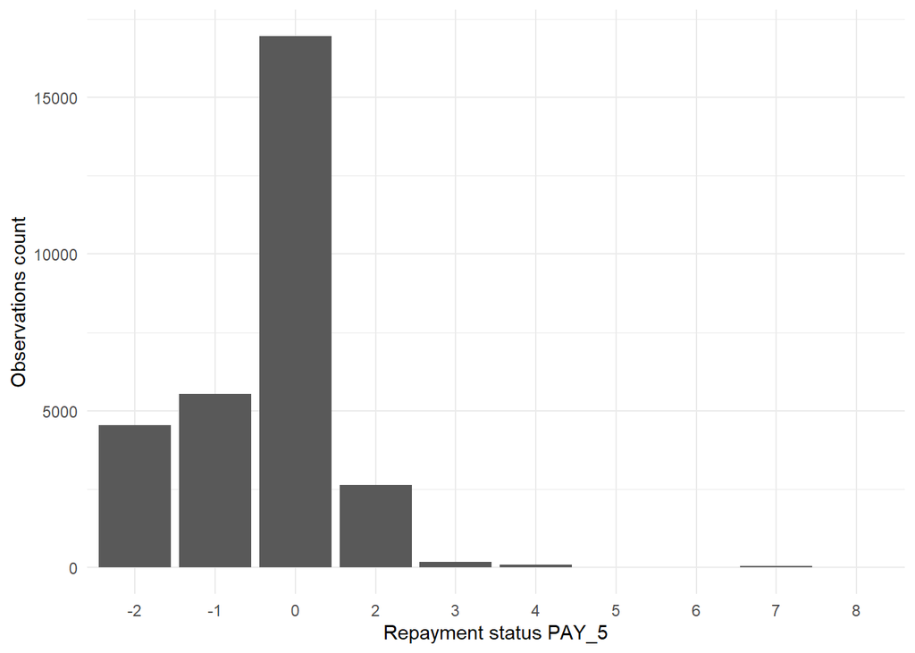

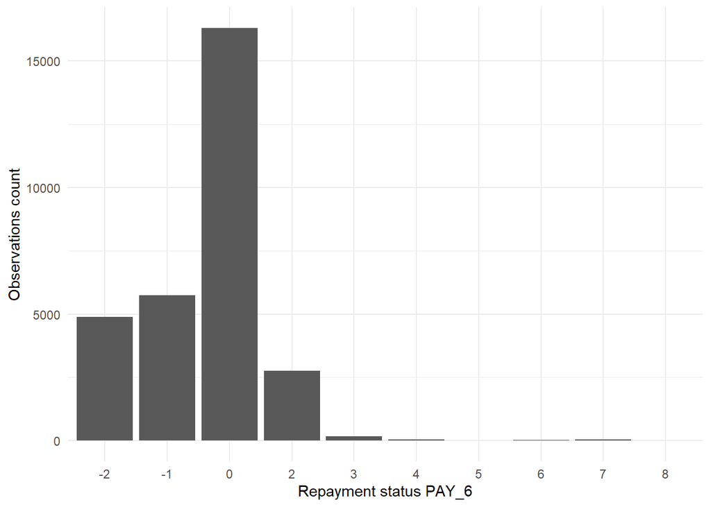

```r
  pay.cols.names  <- paste0("PAY_", c(0, 2:6))

cols.to.factors <- c("SEX", "EDUCATION", "MARRIAGE",
                     pay.cols.names, "default_payment")

uci_creditcard[cols.to.factors] <- lapply(uci_creditcard[cols.to.factors], factor)
library(ggplot2)
pay.histograms <-
  lapply(pay.cols.names,
         function (pay.col.name){
           ggplot(data = uci_creditcard[, pay.cols.names],
                  aes(x = uci_creditcard[, pay.col.name])) +
             geom_bar(stat = "count") +
             theme_minimal() +
             xlab(paste0("Repayment status ", pay.col.name)) +
             ylab("Observations count")
         })
pay.histograms
```

#histogram data

```r
a<-ggplot(data = uci_creditcard, aes(x = AGE)) +
  geom_histogram(bins = 50, fill = "purple", col = "blue", alpha = 0.3) +
  labs(title = "AGE")+
  scale_x_continuous(breaks = seq(min(0), max(90), by = 5), na.value = TRUE)


b<-ggplot(data = uci_creditcard, aes(x= BILL_AMT1)) +
  geom_histogram(bins = 50, fill = "purple", col = "blue", alpha = 0.3) +
  labs(title = "BILL_AMT1")+
  scale_x_continuous(breaks = seq(min(0), max(90), by = 5), na.value = TRUE)


c<-ggplot(data = uci_creditcard, aes(x= BILL_AMT2)) +
  geom_histogram(bins = 50, fill = "purple", col = "blue", alpha = 0.3) + labs(title = "BILL_AMT2")+
  scale_x_continuous(breaks = seq(min(0), max(90), by = 5), na.value = TRUE)

d<-ggplot(data = uci_creditcard, aes(x= BILL_AMT3)) +
  geom_histogram(bins = 50, fill = "purple", col = "blue", alpha = 0.3) +  labs(title = "BILL_AMT3")+
  scale_x_continuous(breaks = seq(min(0), max(90), by = 5), na.value = TRUE)
grid.arrange(a, b,ncol=2)
```

[output not shown]

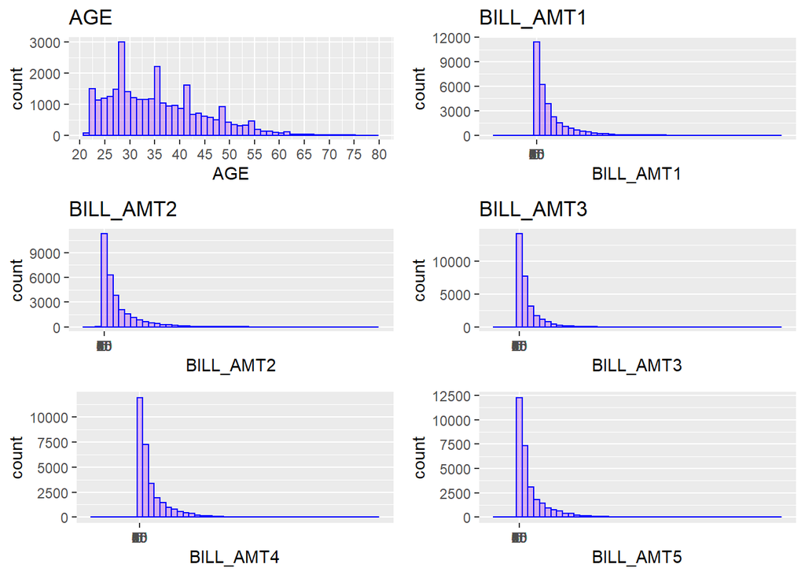

```r
e<-ggplot(data = uci_creditcard, aes(x= BILL_AMT4)) +
  geom_histogram(bins = 50, fill = "purple", col = "blue", alpha = 0.3) +
  scale_x_continuous(breaks = seq(min(0), max(90), by = 5), na.value = TRUE)


f<-ggplot(data = uci_creditcard, aes(x= BILL_AMT5)) +
  geom_histogram(bins = 50, fill = "purple", col = "blue", alpha = 0.3) +
  scale_x_continuous(breaks = seq(min(0), max(90), by = 5), na.value = TRUE)

grid.arrange(a,b,c,d,e,f,ncol=2)
```

```r
g<-ggplot(data = uci_creditcard, aes(x= EDUCATION)) +
  geom_histogram(bins = 50, fill = "purple", col = "blue", alpha = 0.3) +
  scale_x_continuous(breaks = seq(min(0), max(90), by = 5), na.value = TRUE)
grid.arrange(a, b,ncol=2)
```

[output not shown]

```r
h<-ggplot(data = uci_creditcard, aes(x= LIMIT_BAL)) +
  geom_histogram(bins = 50, fill = "purple", col = "blue", alpha = 0.3) +
  scale_x_continuous(breaks = seq(min(0), max(90), by = 5), na.value = TRUE)
grid.arrange(a, b,ncol=2)
```

[output not shown]

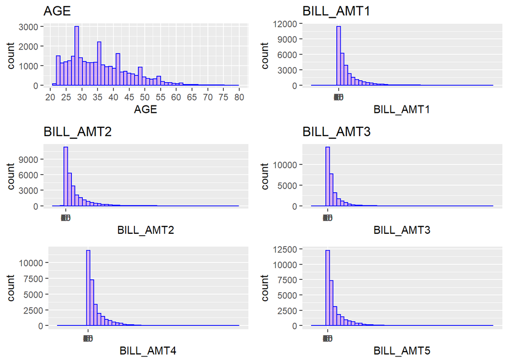

```r
grid.arrange(a,b,c,d,e,f,ncol=2)
```

#Feature selection by using random forest

```r
data.partition<-sample(2,nrow(uci_creditcard),replace = TRUE,prob = c(0.75,0.25))
data.train<-uci_creditcard[data.partition==1,]
data.test<-uci_creditcard[data.partition==2,]


library(randomForest)
output.forest <- randomForest(default_payment~ LIMIT_BAL +SEX+ EDUCATION + MARRIAGE +
                                  AGE +PAY_0 +PAY_2+ PAY_3+PAY_4+PAY_5+PAY_6+BILL_AMT1+
                                  BILL_AMT2+BILL_AMT3+BILL_AMT4+BILL_AMT5+ BILL_AMT6+
                                  PAY_AMT1+PAY_AMT2+PAY_AMT3+PAY_AMT4+PAY_AMT5+PAY_AMT6, data = data.train)



Import.vari<-importance(output.forest)
Import.vari
```

```
##           MeanDecreaseGini
## LIMIT_BAL        398.39989
## SEX               73.15164
## EDUCATION        145.69129
## MARRIAGE          88.56479
## AGE              433.82452
## PAY_0            785.97801
## PAY_2            345.87591
## PAY_3            213.56373
## PAY_4            176.66538
## PAY_5            160.38519
## PAY_6            154.01602
## BILL_AMT1        456.86054
## BILL_AMT2        413.32790
## BILL_AMT3        395.61984
## BILL_AMT4        383.80940
## BILL_AMT5        379.30381
## BILL_AMT6        383.11915
## PAY_AMT1         386.75856
## PAY_AMT2         367.00496
## PAY_AMT3         355.30962
## PAY_AMT4         334.08457
## PAY_AMT5         332.21296
## PAY_AMT6         347.88980
```

#implement models

```r
library(caret)
library(rpart)
library(rpart.plot)
library(rminer)
library(ggplot2)
library(Amelia)
library(nnet)
library(dummies)
library(caTools)
```

#according to corrrolation&highly corrolated feature &feature selection that has been done we will remove some attribute

```r
uci_creditcard$BILL_AMT6 <- NULL
uci_creditcard$BILL_AMT5<- NULL
uci_creditcard$BILL_AMT4<- NULL
uci_creditcard$BILL_AMT3<- NULL
uci_creditcard$BILL_AMT2<- NULL

uci_creditcard$PAY_2<- NULL
uci_creditcard$PAY_3<- NULL
uci_creditcard$PAY_4<- NULL
uci_creditcard$PAY_5<- NULL
uci_creditcard$PAY_6<- NULL
str(uci_creditcard)
```

```
## 'data.frame':    30000 obs. of  14 variables:
##  $ LIMIT_BAL      : num  20000 120000 90000 50000 50000 50000 500000 100000 140000 20000 ...
##  $ SEX            : Factor w/ 2 levels "Male","Female": 2 2 2 2 1 1 1 2 2 1 ...
##  $ EDUCATION      : Factor w/ 5 levels "Unknown","Graduate School",..: 3 3 3 3 3 2 2 3 4 4 ...
##  $ MARRIAGE       : Factor w/ 4 levels "Unknown","Married",..: 2 3 3 2 2 3 3 3 2 3 ...
##  $ AGE            : num  24 26 34 37 57 37 29 23 28 35 ...
##  $ PAY_0          : Factor w/ 11 levels "-2","-1","0",..: 5 2 3 3 2 3 3 3 3 1 ...
##  $ BILL_AMT1      : num  3913 2682 29239 46990 8617 ...
##  $ PAY_AMT1       : num  0 0 1518 2000 2000 ...
##  $ PAY_AMT2       : num  689 1000 1500 2019 36681 ...
##  $ PAY_AMT3       : num  0 1000 1000 1200 10000 657 38000 0 432 0 ...
##  $ PAY_AMT4       : num  0 1000 1000 1100 9000 ...
##  $ PAY_AMT5       : num  0 0 1000 1069 689 ...
##  $ PAY_AMT6       : num  0 2000 5000 1000 679 ...
##  $ default_payment: Factor w/ 2 levels "No","Yes": 2 2 1 1 1 1 1 1 1 1 ...
```

#Normalize Data

```r
normalize <- function(x) {
               return ((x - min(x)) / (max(x) - min(x))) }

uci_creditcard1 <- as.data.frame(lapply(uci_creditcard[7:13], normalize))
uci_creditcard2 <- as.data.frame(lapply(uci_creditcard[1], normalize))
uci_creditcard3 <- as.data.frame(lapply(uci_creditcard[5], normalize))

uci_creditcard <- cbind(uci_creditcard2,uci_creditcard$SEX,uci_creditcard$EDUCATION,uci_creditcard$MARRIAGE,
                        uci_creditcard3,uci_creditcard$PAY_0,uci_creditcard1,uci_creditcard$default_payment)
str(uci_creditcard)
```

```
## 'data.frame':    30000 obs. of  14 variables:
##  $ LIMIT_BAL                     : num  0.0101 0.1111 0.0808 0.0404 0.0404 ...
##  $ uci_creditcard$SEX            : Factor w/ 2 levels "Male","Female": 2 2 2 2 1 1 1 2 2 1 ...
##  $ uci_creditcard$EDUCATION      : Factor w/ 5 levels "Unknown","Graduate School",..: 3 3 3 3 3 2 2 3 4 4 ...
##  $ uci_creditcard$MARRIAGE       : Factor w/ 4 levels "Unknown","Married",..: 2 3 3 2 2 3 3 3 2 3 ...
##  $ AGE                           : num  0.0517 0.0862 0.2241 0.2759 0.6207 ...
##  $ uci_creditcard$PAY_0          : Factor w/ 11 levels "-2","-1","0",..: 5 2 3 3 2 3 3 3 3 1 ...
##  $ BILL_AMT1                     : num  0.15 0.149 0.172 0.188 0.154 ...
##  $ PAY_AMT1                      : num  0 0 0.00174 0.00229 0.00229 ...
##  $ PAY_AMT2                      : num  0.000409 0.000594 0.000891 0.001199 0.021779 ...
##  $ PAY_AMT3                      : num  0 0.00112 0.00112 0.00134 0.01116 ...
##  $ PAY_AMT4                      : num  0 0.00161 0.00161 0.00177 0.01449 ...
##  $ PAY_AMT5                      : num  0 0 0.00234 0.00251 0.00162 ...
##  $ PAY_AMT6                      : num  0 0.00378 0.00946 0.00189 0.00128 ...
##  $ uci_creditcard$default_payment: Factor w/ 2 levels "No","Yes": 2 2 1 1 1 1 1 1 1 1 ...
```

```r
colnames(uci_creditcard)[colnames(uci_creditcard)=="uci_creditcard$SEX"] <- "SEX"
colnames(uci_creditcard)[colnames(uci_creditcard)=="uci_creditcard$EDUCATION"] <- "EDUCATION"
colnames(uci_creditcard)[colnames(uci_creditcard)=="uci_creditcard$MARRIAGE"] <- "MARRIAGE"
colnames(uci_creditcard)[colnames(uci_creditcard)=="uci_creditcard$default_payment"] <- "default_payment"
colnames(uci_creditcard)[colnames(uci_creditcard)=="uci_creditcard$PAY_0"] <- "PAY_0"
str(uci_creditcard)
```

```
## 'data.frame':    30000 obs. of  14 variables:
##  $ LIMIT_BAL      : num  0.0101 0.1111 0.0808 0.0404 0.0404 ...
##  $ SEX            : Factor w/ 2 levels "Male","Female": 2 2 2 2 1 1 1 2 2 1 ...
##  $ EDUCATION      : Factor w/ 5 levels "Unknown","Graduate School",..: 3 3 3 3 3 2 2 3 4 4 ...
##  $ MARRIAGE       : Factor w/ 4 levels "Unknown","Married",..: 2 3 3 2 2 3 3 3 2 3 ...
##  $ AGE            : num  0.0517 0.0862 0.2241 0.2759 0.6207 ...
##  $ PAY_0          : Factor w/ 11 levels "-2","-1","0",..: 5 2 3 3 2 3 3 3 3 1 ...
##  $ BILL_AMT1      : num  0.15 0.149 0.172 0.188 0.154 ...
##  $ PAY_AMT1       : num  0 0 0.00174 0.00229 0.00229 ...
##  $ PAY_AMT2       : num  0.000409 0.000594 0.000891 0.001199 0.021779 ...
##  $ PAY_AMT3       : num  0 0.00112 0.00112 0.00134 0.01116 ...
##  $ PAY_AMT4       : num  0 0.00161 0.00161 0.00177 0.01449 ...
##  $ PAY_AMT5       : num  0 0 0.00234 0.00251 0.00162 ...
##  $ PAY_AMT6       : num  0 0.00378 0.00946 0.00189 0.00128 ...
##  $ default_payment: Factor w/ 2 levels "No","Yes": 2 2 1 1 1 1 1 1 1 1 ...
```

```r
summary(uci_creditcard)
```

```
##    LIMIT_BAL          SEX                  EDUCATION        MARRIAGE
##  Min.   :0.0000   Male  :11888   Unknown        :  345   Unknown:   54
##  1st Qu.:0.0404   Female:18112   Graduate School:10585   Married:13659
##  Median :0.1313                  University     :14030   Single :15964
##  Mean   :0.1591                  High school    : 4917   Others :  323
##  3rd Qu.:0.2323                  Others         :  123
##  Max.   :1.0000
##
##       AGE             PAY_0         BILL_AMT1         PAY_AMT1
##  Min.   :0.0000   0      :14737   Min.   :0.0000   Min.   :0.000000
##  1st Qu.:0.1207   -1     : 5686   1st Qu.:0.1497   1st Qu.:0.001145
##  Median :0.2241   1      : 3688   Median :0.1663   Median :0.002404
##  Mean   :0.2497   -2     : 2759   Mean   :0.1918   Mean   :0.006483
##  3rd Qu.:0.3448   2      : 2667   3rd Qu.:0.2059   3rd Qu.:0.005731
##  Max.   :1.0000   3      :  322   Max.   :1.0000   Max.   :1.000000
##                   (Other):  141
##     PAY_AMT2            PAY_AMT3            PAY_AMT4            PAY_AMT5
##  Min.   :0.0000000   Min.   :0.0000000   Min.   :0.0000000   Min.   :0.000000
##  1st Qu.:0.0004946   1st Qu.:0.0004352   1st Qu.:0.0004767   1st Qu.:0.000592
##  Median :0.0011928   Median :0.0020088   Median :0.0024155   Median :0.003517
##  Mean   :0.0035156   Mean   :0.0058320   Mean   :0.0077715   Mean   :0.011252
##  3rd Qu.:0.0029687   3rd Qu.:0.0050277   3rd Qu.:0.0064626   3rd Qu.:0.009452
##  Max.   :1.0000000   Max.   :1.0000000   Max.   :1.0000000   Max.   :1.000000
##
##     PAY_AMT6         default_payment
##  Min.   :0.0000000   No :23364
##  1st Qu.:0.0002227   Yes: 6636
##  Median :0.0028373
##  Mean   :0.0098654
##  3rd Qu.:0.0075662
##  Max.   :1.0000000
##
```

#Convert Factor level into dummy variable

```r
SEX.dummies<-dummy(uci_creditcard$SEX,sep = '_')
EDUCATION.dummy<-dummy(uci_creditcard$EDUCATION,sep = '_')
MARRIAGE.dummy<-dummy(uci_creditcard$MARRIAGE,sep = '_')
PAY_0.dummies<-dummy(uci_creditcard$PAY_0,sep = '_')
uci_creditcard_clean<-cbind(uci_creditcard,MARRIAGE.dummy,SEX.dummies,EDUCATION.dummy,PAY_0.dummies)
dim(uci_creditcard_clean)
```

```
## [1] 30000    36
```

```r
uci_creditcard_clean<-uci_creditcard_clean[,c(1,5,7:36)]
dim(uci_creditcard_clean)
```

```
## [1] 30000    32
```

```r
str(uci_creditcard_clean)
```

```
## 'data.frame':    30000 obs. of  32 variables:
##  $ LIMIT_BAL                                                                                     : num  0.0101 0.1111 0.0808 0.0404 0.0404 ...
##  $ AGE                                                                                           : num  0.0517 0.0862 0.2241 0.2759 0.6207 ...
##  $ BILL_AMT1                                                                                     : num  0.15 0.149 0.172 0.188 0.154 ...
##  $ PAY_AMT1                                                                                      : num  0 0 0.00174 0.00229 0.00229 ...
##  $ PAY_AMT2                                                                                      : num  0.000409 0.000594 0.000891 0.001199 0.021779 ...
##  $ PAY_AMT3                                                                                      : num  0 0.00112 0.00112 0.00134 0.01116 ...
##  $ PAY_AMT4                                                                                      : num  0 0.00161 0.00161 0.00177 0.01449 ...
##  $ PAY_AMT5                                                                                      : num  0 0 0.00234 0.00251 0.00162 ...
##  $ PAY_AMT6                                                                                      : num  0 0.00378 0.00946 0.00189 0.00128 ...
##  $ default_payment                                                                               : Factor w/ 2 levels "No","Yes": 2 2 1 1 1 1 1 1 1 1 ...
##  $ C:/Users/yastr/OneDrive/Desktop/data analyst/project/CreditCartDefaultCode.Rmd_Unknown        : int  0 0 0 0 0 0 0 0 0 0 ...
##  $ C:/Users/yastr/OneDrive/Desktop/data analyst/project/CreditCartDefaultCode.Rmd_Married        : int  1 0 0 1 1 0 0 0 1 0 ...
##  $ C:/Users/yastr/OneDrive/Desktop/data analyst/project/CreditCartDefaultCode.Rmd_Single         : int  0 1 1 0 0 1 1 1 0 1 ...
##  $ C:/Users/yastr/OneDrive/Desktop/data analyst/project/CreditCartDefaultCode.Rmd_Others         : int  0 0 0 0 0 0 0 0 0 0 ...
```

[output cut: 18 more lines]

#data partition

```r
uci_creditcard_clean_index <- sample(1:nrow(uci_creditcard_clean), 0.7 * nrow(uci_creditcard_clean))
train.set <- uci_creditcard_clean[uci_creditcard_clean_index ,]
test.set  <- uci_creditcard_clean[-uci_creditcard_clean_index ,]
dim(train.set)
```

```
## [1] 21000    32
```

```r
dim(test.set)
```

```
## [1] 9000   32
```

```r
str(test.set)
```

```
## 'data.frame':    9000 obs. of  32 variables:
##  $ LIMIT_BAL                                                                                     : num  0.3535 0.0808 0.0404 0.0404 0.0909 ...
##  $ AGE                                                                                           : num  0.4828 0.0345 0.1552 0.0862 0.1897 ...
##  $ BILL_AMT1                                                                                     : num  0.147 0.151 0.166 0.16 0.229 ...
##  $ PAY_AMT1                                                                                      : num  0 0.00659 0.00149 0.00172 0.00346 ...
##  $ PAY_AMT2                                                                                      : num  0 0 0.000772 0.000891 0.002085 ...
##  $ PAY_AMT3                                                                                      : num  0 0.00602 0.00112 0.00112 0.00369 ...
##  $ PAY_AMT4                                                                                      : num  0 0.00193 0.00242 0.00161 0.00516 ...
##  $ PAY_AMT5                                                                                      : num  0 0.00479 0.00234 0.00375 0.0075 ...
##  $ PAY_AMT6                                                                                      : num  0 0.00378 0.00191 0 0.00474 ...
##  $ default_payment                                                                               : Factor w/ 2 levels "No","Yes": 1 1 1 1 1 1 1 1 1 1 ...
##  $ C:/Users/yastr/OneDrive/Desktop/data analyst/project/CreditCartDefaultCode.Rmd_Unknown        : int  0 0 0 0 0 0 0 0 0 0 ...
##  $ C:/Users/yastr/OneDrive/Desktop/data analyst/project/CreditCartDefaultCode.Rmd_Married        : int  1 0 0 0 0 1 0 0 0 0 ...
##  $ C:/Users/yastr/OneDrive/Desktop/data analyst/project/CreditCartDefaultCode.Rmd_Single         : int  0 1 1 1 1 0 1 1 1 1 ...
##  $ C:/Users/yastr/OneDrive/Desktop/data analyst/project/CreditCartDefaultCode.Rmd_Others         : int  0 0 0 0 0 0 0 0 0 0 ...
```

[output cut: 18 more lines]

#Model1 Logistic Regression

```r
StartLG<-Sys.time()
log.model<-glm(default_payment~.,family = "binomial",train.set)
EndLG<-Sys.time()

summary(log.model)
```

```
##
## Call:
## glm(formula = default_payment ~ ., family = "binomial", data = train.set)
##
## Deviance Residuals:
##     Min       1Q   Median       3Q      Max
## -1.8204  -0.6121  -0.5297  -0.3166   3.1777
##
## Coefficients: (4 not defined because of singularities)
##                                                                                                   Estimate
## (Intercept)                                                                                       -1.37160
## LIMIT_BAL                                                                                         -2.32331
## AGE                                                                                                0.15841
## BILL_AMT1                                                                                          2.55024
## PAY_AMT1                                                                                         -11.18117
## PAY_AMT2                                                                                         -11.19044
## PAY_AMT3                                                                                          -3.76060
## PAY_AMT4                                                                                          -2.60003
## PAY_AMT5                                                                                          -1.99500
## PAY_AMT6                                                                                          -1.89300
## `C:/Users/yastr/OneDrive/Desktop/data analyst/project/CreditCartDefaultCode.Rmd_Unknown`          -0.61653
## `C:/Users/yastr/OneDrive/Desktop/data analyst/project/CreditCartDefaultCode.Rmd_Married`           0.09913
## `C:/Users/yastr/OneDrive/Desktop/data analyst/project/CreditCartDefaultCode.Rmd_Single`           -0.05818
## `C:/Users/yastr/OneDrive/Desktop/data analyst/project/CreditCartDefaultCode.Rmd_Others`                 NA
## `C:/Users/yastr/OneDrive/Desktop/data analyst/project/CreditCartDefaultCode.Rmd_Male`              0.18681
## `C:/Users/yastr/OneDrive/Desktop/data analyst/project/CreditCartDefaultCode.Rmd_Female`                 NA
## `C:/Users/yastr/OneDrive/Desktop/data analyst/project/CreditCartDefaultCode.Rmd_Unknown.1`         0.12234
## `C:/Users/yastr/OneDrive/Desktop/data analyst/project/CreditCartDefaultCode.Rmd_Graduate School`   1.10501
## `C:/Users/yastr/OneDrive/Desktop/data analyst/project/CreditCartDefaultCode.Rmd_University`        1.12530
## `C:/Users/yastr/OneDrive/Desktop/data analyst/project/CreditCartDefaultCode.Rmd_High school`       1.05912
## `C:/Users/yastr/OneDrive/Desktop/data analyst/project/CreditCartDefaultCode.Rmd_Others.1`               NA
## `C:/Users/yastr/OneDrive/Desktop/data analyst/project/CreditCartDefaultCode.Rmd_-2`               -1.40444
## `C:/Users/yastr/OneDrive/Desktop/data analyst/project/CreditCartDefaultCode.Rmd_-1`               -1.25387
## `C:/Users/yastr/OneDrive/Desktop/data analyst/project/CreditCartDefaultCode.Rmd_0`                -1.81196
## `C:/Users/yastr/OneDrive/Desktop/data analyst/project/CreditCartDefaultCode.Rmd_1`                -0.58643
## `C:/Users/yastr/OneDrive/Desktop/data analyst/project/CreditCartDefaultCode.Rmd_2`                 0.74189
## `C:/Users/yastr/OneDrive/Desktop/data analyst/project/CreditCartDefaultCode.Rmd_3`                 0.90616
## `C:/Users/yastr/OneDrive/Desktop/data analyst/project/CreditCartDefaultCode.Rmd_4`                 0.63602
## `C:/Users/yastr/OneDrive/Desktop/data analyst/project/CreditCartDefaultCode.Rmd_5`                 0.39212
## `C:/Users/yastr/OneDrive/Desktop/data analyst/project/CreditCartDefaultCode.Rmd_6`                 0.69007
```

[output cut: 129 more lines]

```
## `C:/Users/yastr/OneDrive/Desktop/data analyst/project/CreditCartDefaultCode.Rmd_4`
## `C:/Users/yastr/OneDrive/Desktop/data analyst/project/CreditCartDefaultCode.Rmd_5`
## `C:/Users/yastr/OneDrive/Desktop/data analyst/project/CreditCartDefaultCode.Rmd_6`
## `C:/Users/yastr/OneDrive/Desktop/data analyst/project/CreditCartDefaultCode.Rmd_7`
## `C:/Users/yastr/OneDrive/Desktop/data analyst/project/CreditCartDefaultCode.Rmd_8`
## ---
## Signif. codes:  0 '***' 0.001 '**' 0.01 '*' 0.05 '.' 0.1 ' ' 1
##
## (Dispersion parameter for binomial family taken to be 1)
##
##     Null deviance: 22138  on 20999  degrees of freedom
## Residual deviance: 18669  on 20972  degrees of freedom
## AIC: 18725
##
## Number of Fisher Scoring iterations: 6
```

```r
#confint(log.model,level=.95)
default_predction<-predict(log.model,test.set,type='response')
```

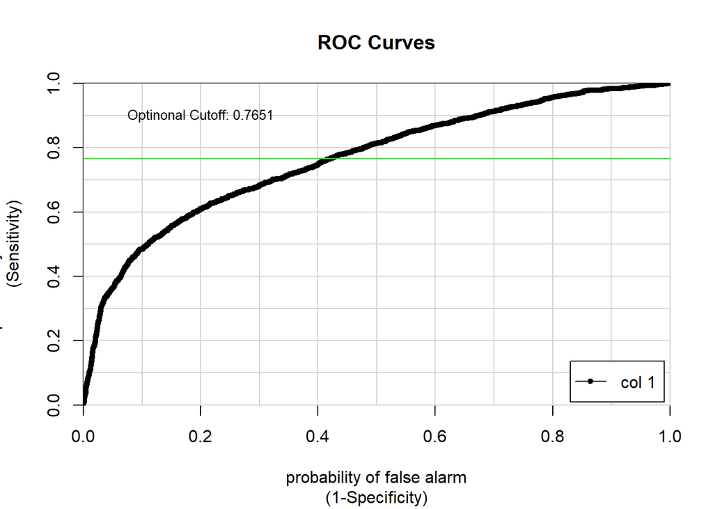

```r
#Generate ROC curve
model.AUC<-colAUC(default_predction,test.set$default_payment,plotROC = T)
abline(h=model.AUC,col='Green')
text(.2,.9,cex = .8,labels = paste("Optinonal Cutoff:",round(model.AUC,4)))
```

```r
#Convert probabilities to class
default.class<-ifelse(default_predction>0.7651,1,0)

#transform back to factor for comparison
default.class<-factor(default.class)
test.set$default_payment<-factor(test.set$default_payment)

library(plyr)
test.set$default_payment <- revalue(test.set$default_payment, c("Yes"=1))
test.set$default_payment <- revalue(test.set$default_payment, c("No"=0))



#levels(as.factor(default.class))
#levels(as.factor(test.set$default_payment))

#Confusion Matrix
confusionMatrix(default.class,test.set$default_payment)
```

```
## Confusion Matrix and Statistics
##
##           Reference
## Prediction    0    1
##          0 6980 1995
##          1    7   18
##
##                Accuracy : 0.7776
##                  95% CI : (0.7688, 0.7861)
##     No Information Rate : 0.7763
##     P-Value [Acc > NIR] : 0.3961
##
##                   Kappa : 0.0122
##
##  Mcnemar's Test P-Value : <2e-16
##
##             Sensitivity : 0.998998
##             Specificity : 0.008942
##          Pos Pred Value : 0.777716
##          Neg Pred Value : 0.720000
##              Prevalence : 0.776333
##          Detection Rate : 0.775556
##    Detection Prevalence : 0.997222
##       Balanced Accuracy : 0.503970
##
##        'Positive' Class : 0
##
```

```r
time<-EndLG-StartLG
cat("execution time is :",time )
```

```
## execution time is : 0.2732689
```

####Second model Neural Network

```r
StartNN<-Sys.time()
NNlog<-multinom(default_payment~.,data = train.set)
EndNN<-Sys.time()

summary(NNlog)
```

```
## Call:
## multinom(formula = default_payment ~ ., data = train.set)
##
## Coefficients:
##                                                                                                        Values
## (Intercept)                                                                                       -0.42272230
## LIMIT_BAL                                                                                         -2.32328118
## AGE                                                                                                0.15843941
## BILL_AMT1                                                                                          2.55017276
## PAY_AMT1                                                                                         -11.18209213
## PAY_AMT2                                                                                         -11.18971341
## PAY_AMT3                                                                                          -3.76031823
## PAY_AMT4                                                                                          -2.59987515
## PAY_AMT5                                                                                          -1.99486661
## PAY_AMT6                                                                                          -1.89297905
## `C:/Users/yastr/OneDrive/Desktop/data analyst/project/CreditCartDefaultCode.Rmd_Unknown`          -0.57823465
## `C:/Users/yastr/OneDrive/Desktop/data analyst/project/CreditCartDefaultCode.Rmd_Married`           0.13732595
## `C:/Users/yastr/OneDrive/Desktop/data analyst/project/CreditCartDefaultCode.Rmd_Single`           -0.01998389
## `C:/Users/yastr/OneDrive/Desktop/data analyst/project/CreditCartDefaultCode.Rmd_Others`            0.03817029
## `C:/Users/yastr/OneDrive/Desktop/data analyst/project/CreditCartDefaultCode.Rmd_Male`             -0.11795550
## `C:/Users/yastr/OneDrive/Desktop/data analyst/project/CreditCartDefaultCode.Rmd_Female`           -0.30476680
## `C:/Users/yastr/OneDrive/Desktop/data analyst/project/CreditCartDefaultCode.Rmd_Unknown.1`        -0.64481278
## `C:/Users/yastr/OneDrive/Desktop/data analyst/project/CreditCartDefaultCode.Rmd_Graduate School`   0.33822752
## `C:/Users/yastr/OneDrive/Desktop/data analyst/project/CreditCartDefaultCode.Rmd_University`        0.35852488
## `C:/Users/yastr/OneDrive/Desktop/data analyst/project/CreditCartDefaultCode.Rmd_High school`       0.29233850
## `C:/Users/yastr/OneDrive/Desktop/data analyst/project/CreditCartDefaultCode.Rmd_Others.1`         -0.76700042
## `C:/Users/yastr/OneDrive/Desktop/data analyst/project/CreditCartDefaultCode.Rmd_-2`               -1.31995383
## `C:/Users/yastr/OneDrive/Desktop/data analyst/project/CreditCartDefaultCode.Rmd_-1`               -1.16939346
## `C:/Users/yastr/OneDrive/Desktop/data analyst/project/CreditCartDefaultCode.Rmd_0`                -1.72747531
## `C:/Users/yastr/OneDrive/Desktop/data analyst/project/CreditCartDefaultCode.Rmd_1`                -0.50195951
## `C:/Users/yastr/OneDrive/Desktop/data analyst/project/CreditCartDefaultCode.Rmd_2`                 0.82636221
## `C:/Users/yastr/OneDrive/Desktop/data analyst/project/CreditCartDefaultCode.Rmd_3`                 0.99065415
## `C:/Users/yastr/OneDrive/Desktop/data analyst/project/CreditCartDefaultCode.Rmd_4`                 0.72051255
## `C:/Users/yastr/OneDrive/Desktop/data analyst/project/CreditCartDefaultCode.Rmd_5`                 0.47657910
## `C:/Users/yastr/OneDrive/Desktop/data analyst/project/CreditCartDefaultCode.Rmd_6`                 0.77447790
## `C:/Users/yastr/OneDrive/Desktop/data analyst/project/CreditCartDefaultCode.Rmd_7`                 0.42276357
## `C:/Users/yastr/OneDrive/Desktop/data analyst/project/CreditCartDefaultCode.Rmd_8`                 0.08471032
##                                                                                                   Std. Err.
## (Intercept)                                                                                      0.11193878
## LIMIT_BAL                                                                                        0.19748241
```

[output cut: 18 more lines]

```
## `C:/Users/yastr/OneDrive/Desktop/data analyst/project/CreditCartDefaultCode.Rmd_Others.1`        0.36514967
## `C:/Users/yastr/OneDrive/Desktop/data analyst/project/CreditCartDefaultCode.Rmd_-2`              0.14427680
## `C:/Users/yastr/OneDrive/Desktop/data analyst/project/CreditCartDefaultCode.Rmd_-1`              0.13462021
## `C:/Users/yastr/OneDrive/Desktop/data analyst/project/CreditCartDefaultCode.Rmd_0`               0.12936668
## `C:/Users/yastr/OneDrive/Desktop/data analyst/project/CreditCartDefaultCode.Rmd_1`               0.13269210
## `C:/Users/yastr/OneDrive/Desktop/data analyst/project/CreditCartDefaultCode.Rmd_2`               0.13437454
## `C:/Users/yastr/OneDrive/Desktop/data analyst/project/CreditCartDefaultCode.Rmd_3`               0.18703165
## `C:/Users/yastr/OneDrive/Desktop/data analyst/project/CreditCartDefaultCode.Rmd_4`               0.29736274
## `C:/Users/yastr/OneDrive/Desktop/data analyst/project/CreditCartDefaultCode.Rmd_5`               0.45652749
## `C:/Users/yastr/OneDrive/Desktop/data analyst/project/CreditCartDefaultCode.Rmd_6`               0.77435131
## `C:/Users/yastr/OneDrive/Desktop/data analyst/project/CreditCartDefaultCode.Rmd_7`               0.79911306
## `C:/Users/yastr/OneDrive/Desktop/data analyst/project/CreditCartDefaultCode.Rmd_8`               0.50907843
##
## Residual Deviance: 18669.46
## AIC: 18725.46
```

```r
#model Prediction
default_predction2<-predict(NNlog,test.set)
prediction.table<-table(default_predction2,test.set$default_payment)# put information into confusion matrix
prediction.table #print confusion matrix
```

```
##
## default_predction2    0    1
##                No  6731 1348
##                Yes  256  665
```

```r
#Correct Classifiction
sum(diag((prediction.table))/sum(prediction.table))
```

```
## [1] 0.8217778
```

```r
#Misclassification
1-sum(diag((prediction.table))/sum(prediction.table))
```

```
## [1] 0.1782222
```

```r
time<-EndNN-StartNN
cat("execution time is :",time )
```

```
## execution time is : 0.5854318
```

#partition data and manipulate in diffrent way

```r
uci_creditcard$default_paymentF<-factor(uci_creditcard$default_payment)
data.partition<-sample(2,nrow(uci_creditcard),replace = TRUE,prob = c(0.75,0.25))
data.train<-uci_creditcard[data.partition==1,]
data.test<-uci_creditcard[data.partition==2,]
 dim(data.test)
```

```
## [1] 7374   15
```

```r
 str(uci_creditcard)
```

```
## 'data.frame':    30000 obs. of  15 variables:
##  $ LIMIT_BAL       : num  0.0101 0.1111 0.0808 0.0404 0.0404 ...
##  $ SEX             : Factor w/ 2 levels "Male","Female": 2 2 2 2 1 1 1 2 2 1 ...
##  $ EDUCATION       : Factor w/ 5 levels "Unknown","Graduate School",..: 3 3 3 3 3 2 2 3 4 4 ...
##  $ MARRIAGE        : Factor w/ 4 levels "Unknown","Married",..: 2 3 3 2 2 3 3 3 2 3 ...
##  $ AGE             : num  0.0517 0.0862 0.2241 0.2759 0.6207 ...
##  $ PAY_0           : Factor w/ 11 levels "-2","-1","0",..: 5 2 3 3 2 3 3 3 3 1 ...
##  $ BILL_AMT1       : num  0.15 0.149 0.172 0.188 0.154 ...
##  $ PAY_AMT1        : num  0 0 0.00174 0.00229 0.00229 ...
##  $ PAY_AMT2        : num  0.000409 0.000594 0.000891 0.001199 0.021779 ...
##  $ PAY_AMT3        : num  0 0.00112 0.00112 0.00134 0.01116 ...
##  $ PAY_AMT4        : num  0 0.00161 0.00161 0.00177 0.01449 ...
##  $ PAY_AMT5        : num  0 0 0.00234 0.00251 0.00162 ...
##  $ PAY_AMT6        : num  0 0.00378 0.00946 0.00189 0.00128 ...
##  $ default_payment : Factor w/ 2 levels "No","Yes": 2 2 1 1 1 1 1 1 1 1 ...
##  $ default_paymentF: Factor w/ 2 levels "No","Yes": 2 2 1 1 1 1 1 1 1 1 ...
```

#Build Decision Tree

```r
StartDTree<-Sys.time()
d.tree<-rpart(data.train$default_paymentF~data.train$LIMIT_BAL+data.train$SEX+data.train$EDUCATION+data.train$MARRIAGE+
                data.train$PAY_0+data.train$BILL_AMT1+data.train$PAY_AMT6)
EndDTree<-Sys.time()

summary(d.tree)
```

```
## Call:
## rpart(formula = data.train$default_paymentF ~ data.train$LIMIT_BAL +
##     data.train$SEX + data.train$EDUCATION + data.train$MARRIAGE +
##     data.train$PAY_0 + data.train$BILL_AMT1 + data.train$PAY_AMT6)
##   n= 22626
##
##         CP nsplit rel error    xerror       xstd
## 1 0.188653      0  1.000000 1.0000000 0.01241678
## 2 0.010000      1  0.811347 0.8119421 0.01148611
##
## Variable importance
## data.train$PAY_0
##              100
##
## Node number 1: 22626 observations,    complexity param=0.188653
##   predicted class=No   expected loss=0.2227968  P(node) =1
##     class counts: 17585  5041
##    probabilities: 0.777 0.223
##   left son=2 (20249 obs) right son=3 (2377 obs)
##   Primary splits:
##       data.train$PAY_0     splits as  LLLLRRRRRRR, improve=1209.89200, (0 missing)
##       data.train$LIMIT_BAL < 0.1161616   to the right, improve= 183.74090, (0 missing)
##       data.train$PAY_AMT6  < 0.004360976 to the right, improve=  85.02966, (0 missing)
##       data.train$EDUCATION splits as  LLRRL, improve=  36.75773, (0 missing)
##       data.train$SEX       splits as  RL, improve=  11.07639, (0 missing)
##
## Node number 2: 20249 observations
##   predicted class=No   expected loss=0.1667737  P(node) =0.8949439
##     class counts: 16872  3377
##    probabilities: 0.833 0.167
##
## Node number 3: 2377 observations
##   predicted class=Yes  expected loss=0.2999579  P(node) =0.1050561
##     class counts:   713  1664
##    probabilities: 0.300 0.700
```

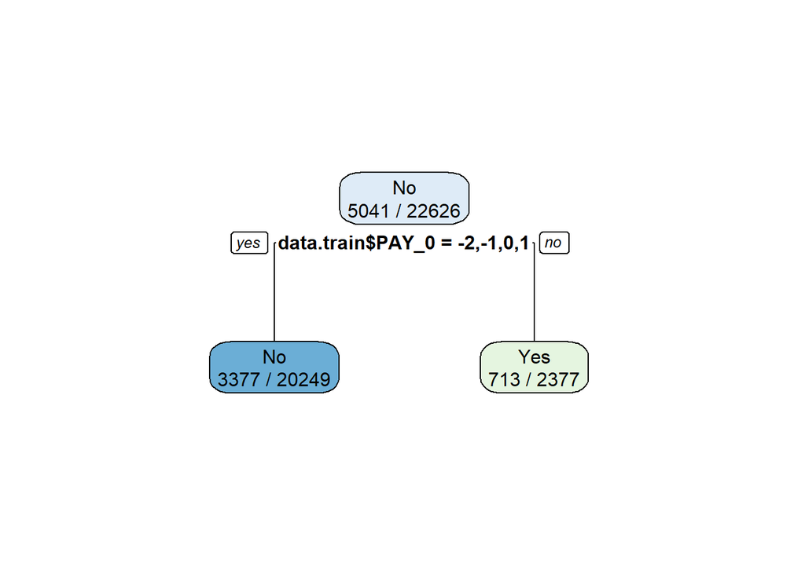

```r
#TO plot decision tree
rpart.plot(d.tree,extra = 3)
```

```r
#default predict
tree.prediction<-predict(d.tree,data.train,type="class")

#to check levels
levels(tree.prediction)
```

```
## [1] "No"  "Yes"
```

```r
levels(data.test$default_paymentF)
```

```
## [1] "No"  "Yes"
```

```r
#Missclasification Matrix
confusionMatrix(tree.prediction,data.train$default_paymentF)
```

```
## Confusion Matrix and Statistics
##
##           Reference
## Prediction    No   Yes
##        No  16872  3377
##        Yes   713  1664
##
##                Accuracy : 0.8192
##                  95% CI : (0.8142, 0.8242)
##     No Information Rate : 0.7772
##     P-Value [Acc > NIR] : < 2.2e-16
##
##                   Kappa : 0.3568
##
##  Mcnemar's Test P-Value : < 2.2e-16
##
##             Sensitivity : 0.9595
##             Specificity : 0.3301
##          Pos Pred Value : 0.8332
##          Neg Pred Value : 0.7000
##              Prevalence : 0.7772
##          Detection Rate : 0.7457
##    Detection Prevalence : 0.8949
##       Balanced Accuracy : 0.6448
##
##        'Positive' Class : No
##
```

```r
time<-EndDTree-StartDTree
cat("execution time is :",time )
```

```
## execution time is : 0.375994
```

#forth Random forest

```r
library(randomForest)
StartRFarest<-Sys.time()
output.forest <- randomForest(data.train$default_paymentF~data.train$LIMIT_BAL+data.train$SEX+data.train$EDUCATION+data.train$MARRIAGE+
                data.train$PAY_0+data.train$BILL_AMT1+data.train$PAY_AMT6,data = data.train)
EndRFarest<-Sys.time()

summary(output.forest)
```

```
##                 Length Class  Mode
## call                3  -none- call
## type                1  -none- character
## predicted       22626  factor numeric
## err.rate         1500  -none- numeric
## confusion           6  -none- numeric
## votes           45252  matrix numeric
## oob.times       22626  -none- numeric
## classes             2  -none- character
## importance          7  -none- numeric
## importanceSD        0  -none- NULL
## localImportance     0  -none- NULL
## proximity           0  -none- NULL
## ntree               1  -none- numeric
## mtry                1  -none- numeric
## forest             14  -none- list
## y               22626  factor numeric
## test                0  -none- NULL
## inbag               0  -none- NULL
## terms               3  terms  call
```

```r
random.prediction<-predict(output.forest,data.train,type="class")
levels(random.prediction)
```

```
## [1] "No"  "Yes"
```

```r
levels(data.test$default_paymentF)
```

```
## [1] "No"  "Yes"
```

```r
confusionMatrix(random.prediction,data.train$default_paymentF)
```

```
## Confusion Matrix and Statistics
##
##           Reference
## Prediction    No   Yes
##        No  17360  2555
##        Yes   225  2486
##
##                Accuracy : 0.8771
##                  95% CI : (0.8728, 0.8814)
##     No Information Rate : 0.7772
##     P-Value [Acc > NIR] : < 2.2e-16
##
##                   Kappa : 0.5752
##
##  Mcnemar's Test P-Value : < 2.2e-16
##
##             Sensitivity : 0.9872
##             Specificity : 0.4932
##          Pos Pred Value : 0.8717
##          Neg Pred Value : 0.9170
##              Prevalence : 0.7772
##          Detection Rate : 0.7673
##    Detection Prevalence : 0.8802
##       Balanced Accuracy : 0.7402
##
##        'Positive' Class : No
##
```

```r
time<-EndRFarest-StartRFarest
cat("execution time is :",time )
```

```
## execution time is : 9.044801
```